# Introduction to data visualization

Malo Jan

## Why data visualization ?

1. Exploration and description
2. Communication
3. Aesthetics

## What makes a bad visualization ?

1. Perceptual (bad)
2. Substantive (wrong)
3. Aesthetics (ugly)

## Ugly charts

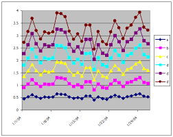

## Wrong charts

[figure not shown]

## Forget about pie charts (the so-called “camemberts”)

- One of the first graphs that comes in our mind when we think about dataviz
- If you have already done that once, it will not happen again
- We want to understand relative sizes but humans are bad at judging angles
- Use barcharts instead : humans are better at judging bar lengths (William Cleveland)

## Bar charts instead of pie charts

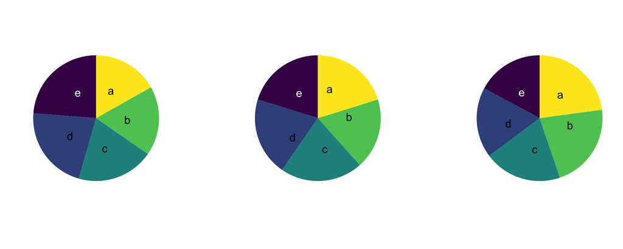

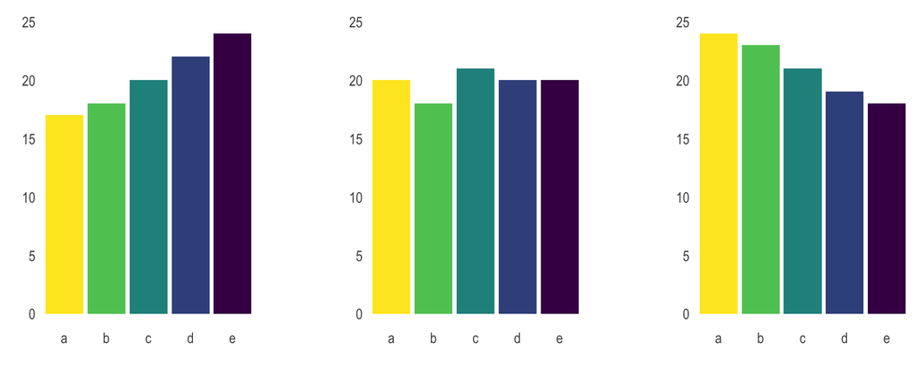

## Forget about double axis

- Misleading
- Difficult to read
- Use several graphs/facets instead

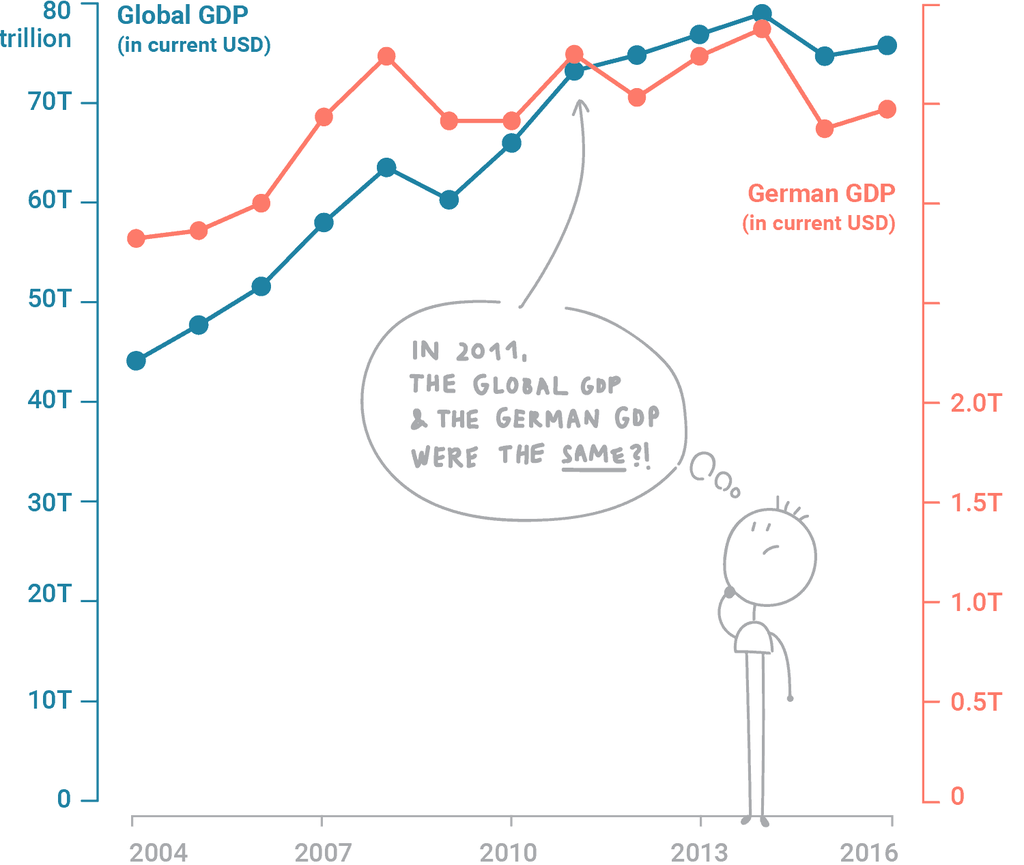

## Many more caveats

- Colors that communicates nothing
- Cutting Y axis
- More caveats [here](https://www.data-to-viz.com/caveats.html)

# The grammar of graphics

## Plotting systems in R

- Base R and functions such as `plot()`, `hist()`, `boxplot()`
- `lattice` package
- The gramar of graphics of `ggplot()`

## Visualization with ggplot()

- Graphs are built by adding various layers allowing to make progressively more complex visualizations
- Three main layers in a ggplot graph :
  - data in a tidy format
  - aesthetics : what are the values that we want to map on the x and y axis, with wich color/shape/size
  - geom : the geometry allows you to specify how you want to represent your data
- Other layers possible : facets, stats, coordinates, themes, statistics…
- Each of those can be add with a `+`